# Map Projections in R

The following section borrows heavily from a tutorial written by Eric Anderson (http://eriqande.github.io/2014/12/24/plotting-sst-with-ggplot.html) for plotting MODIS SST data on a map projection using ggplot2.

I will begin with making a simple map projection and then we can get into adding an additional layers that can be applied to it. You can find many great tutorials for using ggplot2 online.

## Necessary packages

Before we get started, you are going to need to install and load the following packages:

```r
library(maptools)
library(ggplot2)
library(ggrepel)
```

## Creating a map projection

R does not have repositories of the World’s shorelines stored within it, so we need to get those next. You can find the latest coastline files from NOAA at http://www.ngdc.noaa.gov/mgg/shorelines/data/gshhg/latest/. You will need to tell R where to find this file, so keep it in a location that makes sense.

```r
# # Shoreline map
if (!rgeosStatus()) gpclibPermit()
gshhs.f.b <- "/Users/paulmatson/Dropbox/Maps for R/gshhg-bin-2/gshhs_f.b" # your directory path will be different
```

We need to specify what part of the world that we want to project. For this example, let’s create a projection of the Santa Barbara Channel, which will be stored as ‘shore’. It is important that you use the correct format for coordinates: they need to all be in decimal degrees, with latitude in ºN, and longitude is in ºE).  
*Note: I frequently get an error warning after these two lines but the projection still shows up.*

```r
shore <- getRgshhsMap(gshhs.f.b, xlim = c(-120.72, -118.98), ylim = c(33.6, 34.82))
```

```
## Data are polygon data
## Data are polygon data
## Rgshhs: clipping 1 of 10 polygons ...
```

```r
shore <- fortify(shore)
```

Now let’s plug it into the **ggplot()** function and take a look. Again, you can find many great tutorials online that explain the syntax of ggplot2, which differs from the base R **plot()** function.

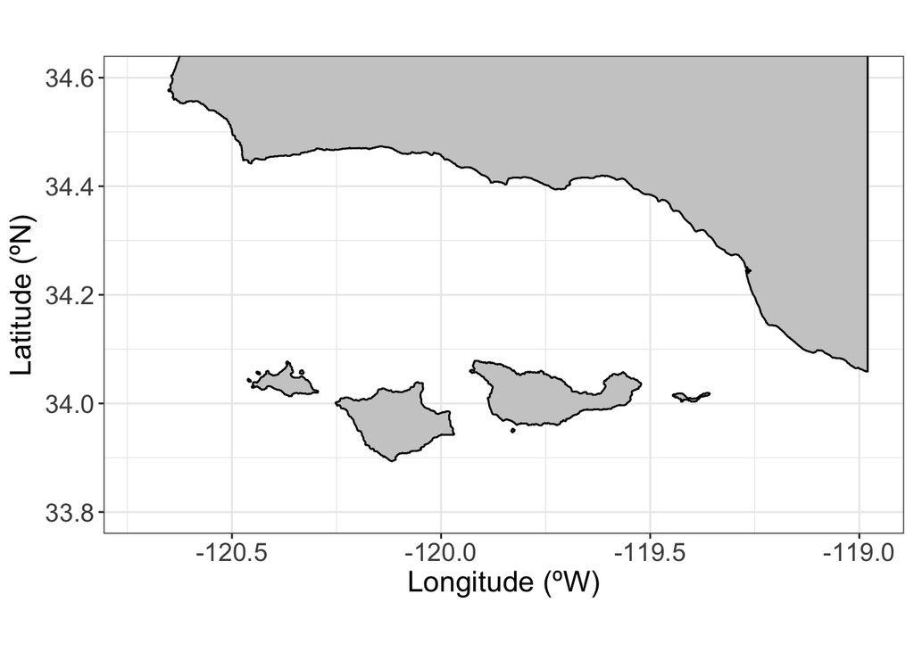

```r
ggplot() +
  geom_polygon(data = shore,
               aes(x=long, y = lat, group = group),
               color = "black", # controls shoreline color
               fill = "grey80") + # controls land color
  coord_fixed(1.3,
              xlim = c(-120.72, -118.98), # sets x limits (should be same as for 'shore')
              ylim = c(33.8, 34.6)) + # sets y limits (should be same as for 'shore')
  labs(x="Longitude (ºW)", y="Latitude (ºN)") +
  theme_bw() +
  theme(axis.text=element_text(size=14), # controls size of axis text
        axis.title=element_text(size=16)) # controls size of axis title
```

Now we want to have some spatial points on our map. In this case, we are going to add in the Plumes and Blooms sampling stations.

```r
# Create dataframe for station locations
# This can also be loaded from a csv file
stations <- data.frame(station = c(seq(1,7,1)), lat = c(34.39158333, 34.34041667, 34.30038333, 34.25096667, 34.20093333, 34.15785, 34.08156667), lon = c(-119.839767, -119.859517, -119.8786, -119.90965, -119.928717, -119.94675, -120.0162))
```

## Adding points

Now let’s plug it into the **ggplot()** function and take a look. Again, you can find many great tutorials online that explain the syntax of ggplot2, which differs from the base R **plot()** function.

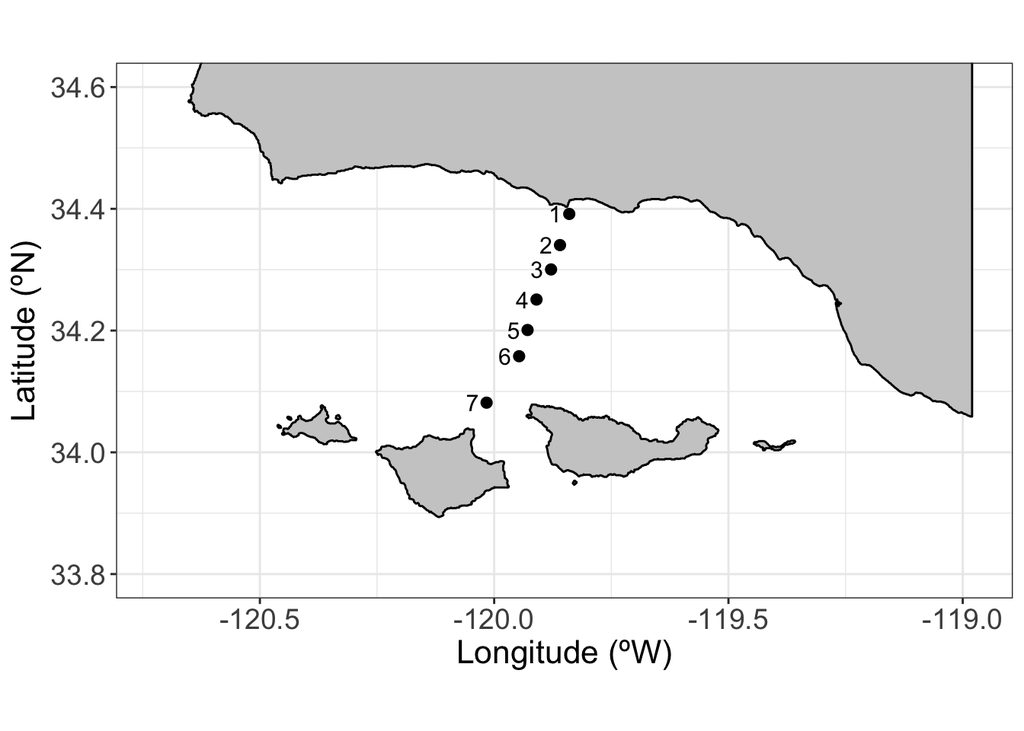

```r
ggplot() +
  geom_polygon(data = shore,
               aes(x=long, y = lat, group = group),
               color = "black", # controls shoreline color
               fill = "grey80") + # controls land color
  coord_fixed(1.3,
              xlim = c(-120.72, -118.98), # sets x limits (should be same as for 'shore')
              ylim = c(33.8, 34.6)) + # sets y limits (should be same as for 'shore')
  labs(x="Longitude (ºW)", y="Latitude (ºN)") +
  geom_point(data=stations,
             mapping = aes(x = lon, y = lat),
             alpha = 1,
             color= "black", # controls color of point
             size = 2.5, # controls relative size of point
             shape = 16) + # controls shape of point
  geom_text(data = stations,
                  aes(label=station, x=lon, y=lat),
                  size=4, # controls text size
                  nudge_x=-0.03) +  # change the distance between point and text (also nudge_y)
  theme_bw() +
  theme(axis.text=element_text(size=14), # controls size of axis text
        axis.title=element_text(size=16)) # controls size of axis title
```

Now try controlling the label text using **geom_text_repel** which uses repulsive textual annotations so they won’t cover each other up.

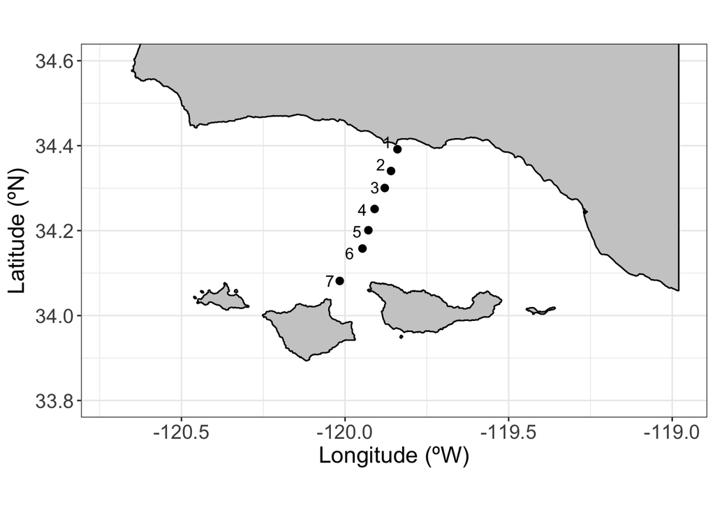

```r
ggplot() +
  geom_polygon(data = shore,
               aes(x=long, y = lat, group = group),
               color = "black", fill = "grey80") +
  coord_fixed(1.3,
              xlim = c(-120.72, -118.98),
              ylim = c(33.8, 34.6)) +
  labs(x="Longitude (ºW)", y="Latitude (ºN)") +
  geom_point(data=stations,
             mapping = aes(x = lon, y = lat),
             alpha = 1,
             color= "black",
             bg= "grey",
             size = 2.5,
             shape = 16) +
  geom_text_repel(data = stations,
                  aes(label=station, x=lon, y=lat),
                  size=4,
                  nudge_x=-0.03) +
  theme_bw() +
  theme(axis.text=element_text(size=14),
        axis.title=element_text(size=16))
```

Finally, if it is difficult to see the labels, you can use **geom_label_repel** which will place a retangular box under the text label and repel each label from its neighbors, similar to **geom_text_repel**.

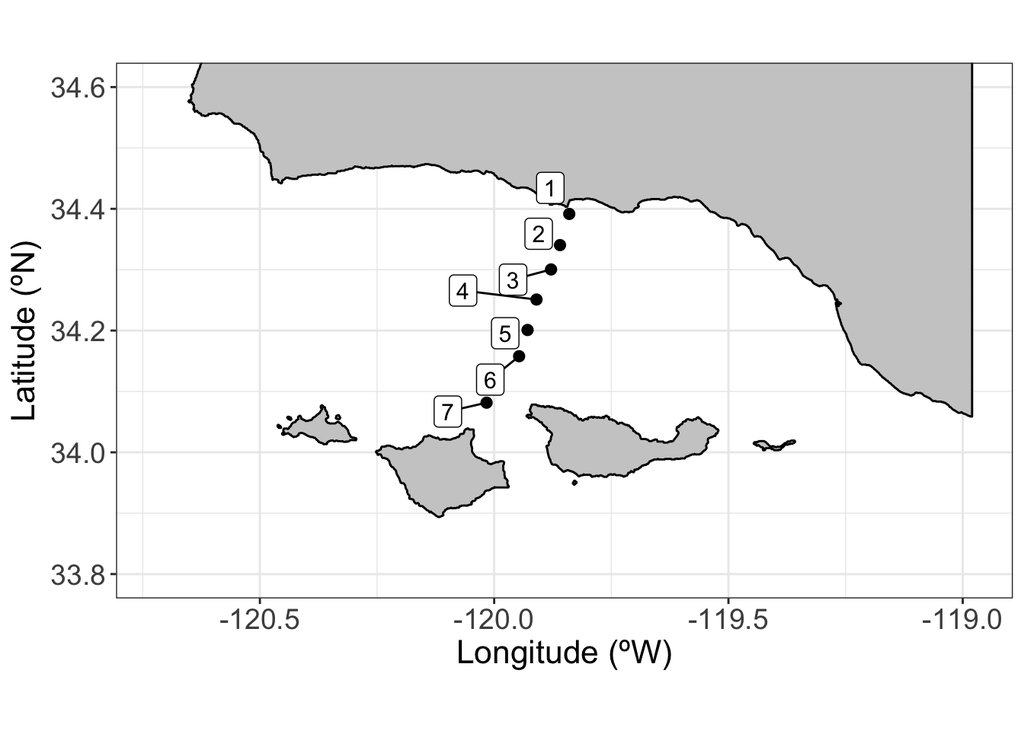

```r
ggplot() +
  geom_polygon(data = shore,
               aes(x=long, y = lat, group = group),
               color = "black",
               fill = "grey80") +
  coord_fixed(1.3,
              xlim = c(-120.72, -118.98),
              ylim = c(33.8, 34.6)) +
  labs(x="Longitude (ºW)", y="Latitude (ºN)") +
  geom_point(data=stations,
             mapping = aes(x = lon, y = lat),
             alpha = 1,
             color= "black",
             size = 2.5,
             shape = 16) +
  geom_label_repel(data = stations,
                  aes(label=station, x=lon, y=lat),
                  size=4,
                  nudge_x=-0.03) +
  theme_bw() +
  theme(axis.text=element_text(size=14),
        axis.title=element_text(size=16))
```

Next let’s try adding in another set of points to our map, in this case we will use high frequency radar stations. These will be plotted with a different style of point.

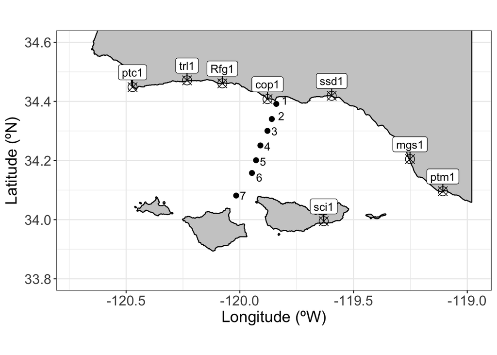

```r
# locations for hf radar stations
hf <- data.frame(radar = c("ptm1","mgs1","ssd1","sci1","cop1","Rfg1","trl1","ptc1"),
                 lon = c(-119.1073667, -119.2516333, -119.5961167, -119.6311667, -119.8783333,
                         -120.0769833, -120.2322333, -120.4717),
                 lat=c(34.0961167, 34.2048833, 34.4190167, 33.9948333, 34.4078333, 34.4610667,
                       34.4711333, 34.4483))

ggplot() +
  geom_polygon(data = shore,
               aes(x=long, y = lat, group = group),
               color = "black",
               fill = "grey80") +
  coord_fixed(1.3,
              xlim = c(-120.72, -118.98),
              ylim = c(33.8, 34.6)) +
  labs(x="Longitude (ºW)", y="Latitude (ºN)") +
  geom_point(data=stations,
             mapping = aes(x = lon, y = lat),
             alpha = 1,
             color= "black",
             size = 2.5,
             shape = 16) +
  geom_point(data=hf, mapping = aes(x = lon, y = lat), alpha = 1,
             color= "black", bg= "grey", size = 4, shape = 13) +
  geom_text_repel(data = stations,
                  aes(label=station, x=lon, y=lat),
                  size=4,
                  nudge_x=0.03) +
  geom_label_repel(data = hf,
                  aes(label=radar, x=lon, y=lat),
                  size=4,
                  nudge_y=0.05) +
  theme_bw() +
  theme(axis.text=element_text(size=14),
        axis.title=element_text(size=16))
```

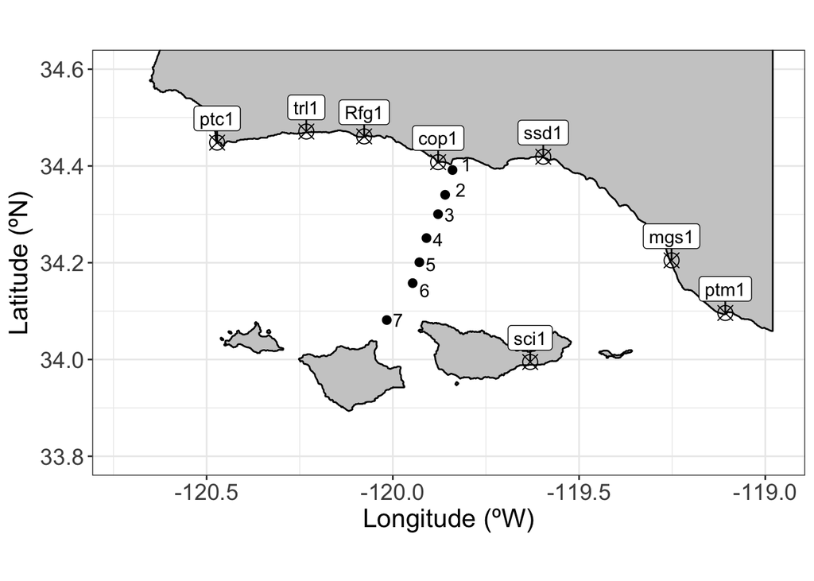

```r
ggplot() +
  geom_polygon(data = shore,
               aes(x=long, y = lat, group = group),
               color = "black",
               fill = "grey80") +
  coord_fixed(1.3,
              xlim = c(-120.72, -118.98),
              ylim = c(33.8, 34.6)) +
  labs(x="Longitude (ºW)", y="Latitude (ºN)") +
  geom_point(data=stations,
             mapping = aes(x = lon, y = lat),
             alpha = 1,
             color= "black",
             size = 2.5,
             shape = 16) +
  geom_point(data=hf, mapping = aes(x = lon, y = lat), alpha = 1,
             color= "black", bg= "grey", size = 4, shape = 13) +
  geom_text_repel(data = stations,
                  aes(label=station, x=lon, y=lat),
                  size=4,
                  nudge_x=0.03) +
  geom_label_repel(data = hf,
                  aes(label=radar, x=lon, y=lat),
                  size=4,
                  nudge_y=0.05) +
  theme_bw() +
  theme(axis.text=element_text(size=14),
        axis.title=element_text(size=16))
```

## Adding in bathymetry

If you want to add another layer of information to your map, you can incorporate bathymetry using the package “marmap”, which you can install using the **install.packages()** function. This package includes a function queries and downloads bathymetric data from NOAA’s ETOPO1 database using coordinates that you provide. Note: the default resolution is 4 minutes of a degree.

```r
# load marmap package
library(marmap)
#query of ETOPO1 data base on NOAA server for bathymetric data, the resolution default is 4 minutes of degree, keep saves the data to a local drive so it doesn't have to quire the NOAA data base,
bathmap <- getNOAA.bathy(lon1 = -120.72, lon2 = -118.98,
                         lat1 = 34.6, lat2 = 33.8, resolution = 1, keep = TRUE)
```

```
## File already exists ; loading 'marmap_coord_-120.72;33.8;-118.98;34.6_res_1.csv'
```

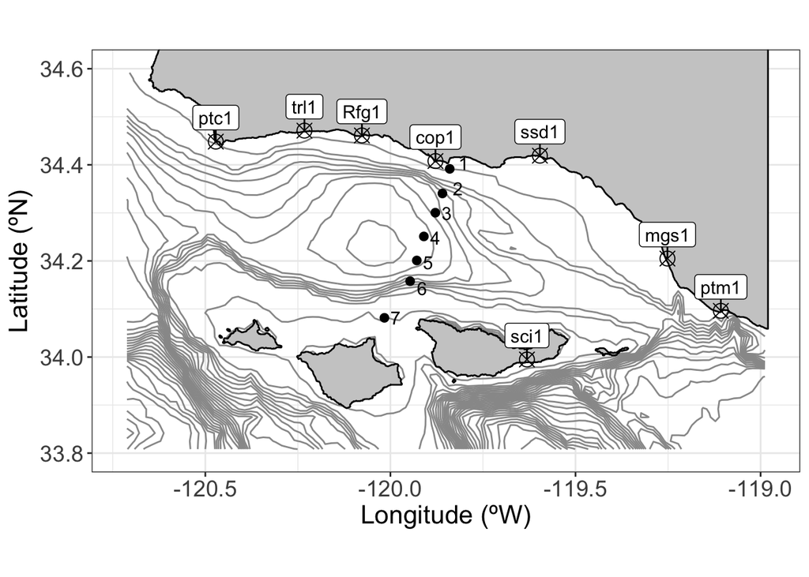

```r
#turn matrix into a data frame
bathmap_df <- fortify.bathy(bathmap)

ggplot() +
  geom_contour(data=bathmap_df, aes(x = x, y = y, z = z),
               bins = 60, # the number of bins determines how many possible depth contours are included
               color = "grey60") + # you can change color of the contours
  geom_polygon(data = shore,
               aes(x=long, y = lat, group = group),
               color = "black",
               fill = "grey80") +
  coord_fixed(1.3,
              xlim = c(-120.72, -118.98),
              ylim = c(33.8, 34.6)) +
  labs(x="Longitude (ºW)", y="Latitude (ºN)") +
  geom_point(data=stations,
             mapping = aes(x = lon, y = lat),
             alpha = 1,
             color= "black",
             size = 2.5,
             shape = 16) +
  geom_point(data=hf, mapping = aes(x = lon, y = lat), alpha = 1,
             color= "black", bg= "grey", size = 4, shape = 13) +
  geom_text_repel(data = stations,
                  aes(label=station, x=lon, y=lat),
                  size=4,
                  nudge_x=0.03) +
  geom_label_repel(data = hf,
                  aes(label=radar, x=lon, y=lat),
                  size=4,
                  nudge_y=0.05) +
  theme_bw() +
  theme(axis.text=element_text(size=14),
        axis.title=element_text(size=16))
```